# GABA-AD: Effect of paired-pulse activation of local GABAARs

## **STUDY DESCRIPTION**

### Aim and hypothesis

The project aims to identify specific changes in our primary outcome measures (TMS-evoked potentials, TEPs) following the pre-activation of local network of cortical interneurons using a paired-pulse TMS protocol. The conditioning stimulus (CS) of a sub-threshold intensity (80%rMT) his used to depolarize the low-threshold inhibitory interneuron at the site of the stimulation, which leads to a decrease in cortical excitability and a weaker response to the subsequent testing stimulus (TS). This phenomenon is called the Short-latency IntraCortical Inhibition (SICI) and was originally measured in motor evoked potentials.

However, we can measure brain’s reaction to TMS more directly with TEPs, and we expect to see changes that will correspond to the increased local GABAA neurotransmission. The size of this effect can be then used to assess the efficiency of the system specifically at the site of stimulation.

### Experimental design

20 subjects participated in 2 experimental sessions. Each session the same measures were taken at the baseline and after medication with either alprazolam (an allosteric BDZ agonist of GABAARs) or placebo.

The questions we aim to answer with our data are as follow: 1) at the baseline, can we see a consistent SICI in TEPs from M1? 2) does the global activation of GABAARs with alprazolam affect the extent of SICI?

### Outcome variables

- **TEP peak amplitude**: measured separately for each TEP component (6 components)
- **SICI**: calculated as the change of the amplitude of each component (simple subtraction) following the piared-pulse stimulation as compared to the simple TS –> this measure serves to evaluate the effect of medication on SICI

### Fixed effect

- **STIMULUS**
  0. single-pulse TS
  1. paired-pulse stimulus
- **MEDICATION**
  0. placebo = control condition
  1. amplrazolam
- Covariate: **rMT change** - continuous value, only used when assessing the effect of medication

### Random effect

- random intercept for each **SUBJECT**

**Following pipeline treats each outcome measure separately, as an independent measure.**

## **STATISTICAL ANALYSIS: BASELINE SICI**

### Import data

Choose a .csv file with either TEP or rsEEG data.

```r
# import the data
input_file <- choose.files(default = folder_dir, caption = "Select the dataset")
data_all <- as_tibble(read.csv(input_file))
names(data_all)
```

[output not shown]

```r
summary(data_all)
```

[output not shown]

### Variable of interest

```r
# variable characteristics
target_peak <- 'P180'

# subset data
data <- data_all %>%
  filter(peak == target_peak) %>%
  mutate(subject = factor(subject)) %>%
  mutate(stimulus = factor(stimulus, levels=c('TS', 'ppTMS'), ordered = TRUE)) %>%
  mutate(medication = factor(medication, levels=c('placebo', 'alprazolam'), ordered = TRUE)) %>%
  select(subject, medication, stimulus, amplitude)
str(data)
```

```
tibble[,4] [80 x 4] (S3: tbl_df/tbl/data.frame)
 $ subject   : Factor w/ 20 levels "1","2","3","4",..: 1 1 1 1 2 2 2 2 3 3 ...
 $ medication: Ord.factor w/ 2 levels "placebo"<"alprazolam": 1 1 2 2 1 1 2 2 1 1 ...
 $ stimulus  : Ord.factor w/ 2 levels "TS"<"ppTMS": 1 2 1 2 1 2 1 2 1 2 ...
 $ amplitude : num [1:80] 3.14 3.35 2.78 2.97 16.62 ...
```

### Descriptive statistics

The distribution is described and visualized for both levels of the factor ‘medication’ separately. The normality is checked both visually (histogram, QQ-plot) and using the Shapiro-Wilk normality test.

```r
# ---- DISTRIBUTION ----
# get summary per medication
data %>%
  select(c(stimulus, medication, amplitude)) %>%
  group_by(stimulus, medication) %>%
  skim()
```

```
-- Data Summary ------------------------
                           Values
Name                       Piped data
Number of rows             80
Number of columns          3
_______________________
Column type frequency:
  numeric                  1
________________________
Group variables            stimulus, medication

-- Variable type: numeric -----------------------------------------------------------------------------------------------------
# A tibble: 4 x 13
  skim_variable stimulus medication n_missing complete_rate  mean    sd    p0   p25   p50   p75  p100 hist
* <chr>         <ord>    <ord>          <int>         <dbl> <dbl> <dbl> <dbl> <dbl> <dbl> <dbl> <dbl> <chr>
1 amplitude     TS       placebo            0             1  7.44  3.76 1.91   4.34  7.06 10.1   16.6 ▇▇▅▃▁
2 amplitude     TS       alprazolam         0             1  7.52  4.25 0.338  5.04  7.95  8.50  19.8 ▅▇▇▁▁
3 amplitude     ppTMS    placebo            0             1  7.61  3.03 3.35   5.32  6.99  9.55  13.7 ▇▇▅▃▂
4 amplitude     ppTMS    alprazolam         0             1  7.63  3.47 2.60   4.41  7.98  9.92  16.6 ▆▃▇▁▁
```

```r
# calculate mean values
data_mean <- data %>%
  group_by(medication, stimulus) %>%
  summarise(mean = mean(amplitude), sd = sd(amplitude), sem = sd(amplitude)/sqrt(20), median = median(amplitude))
data_mean %>%
  knitr::kable()
```

| medication | stimulus | mean | sd | sem | median |
| --- | --- | --- | --- | --- | --- |
| placebo | TS | 7.436 | 3.760 | 0.8409 | 7.060 |
| placebo | ppTMS | 7.609 | 3.026 | 0.6767 | 6.988 |
| alprazolam | TS | 7.518 | 4.250 | 0.9504 | 7.950 |
| alprazolam | ppTMS | 7.635 | 3.470 | 0.7759 | 7.979 |

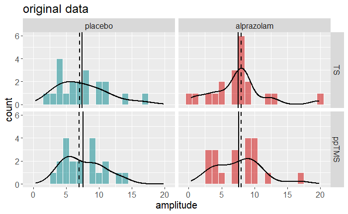

```r
# plot the distribution
data %>%
  ggplot(aes(x = amplitude, y = ..count.., fill = medication)) +
  geom_histogram(binwidth = 1, col = 'white', alpha = 0.5) +
  geom_density(alpha = 0, size = 1) +
  facet_grid(stimulus ~ medication) +
  geom_vline(data = data_mean, aes(xintercept = median), linetype = 'dashed', size = 1) +
  geom_vline(data = data_mean, aes(xintercept = mean), size = 1) +
  ggtitle('original data') +
  ylab('count') +
  xlab('amplitude') +
  theme(text = element_text(size = 15), legend.position = 'none') +
  scale_fill_manual(values = col_palette[c(2, 4)])
```

```r
# skewness and kurtosis
data_shape <- data %>%
  group_by(stimulus, medication) %>%
  summarise(skewness = skewness(amplitude), kurtosis = kurtosis(amplitude))
data_shape %>%
  knitr::kable()
```

| stimulus | medication | skewness | kurtosis |
| --- | --- | --- | --- |
| TS | placebo | 0.7249 | 3.005 |
| TS | alprazolam | 0.9015 | 4.858 |
| ppTMS | placebo | 0.4375 | 2.148 |
| ppTMS | alprazolam | 0.5610 | 3.333 |

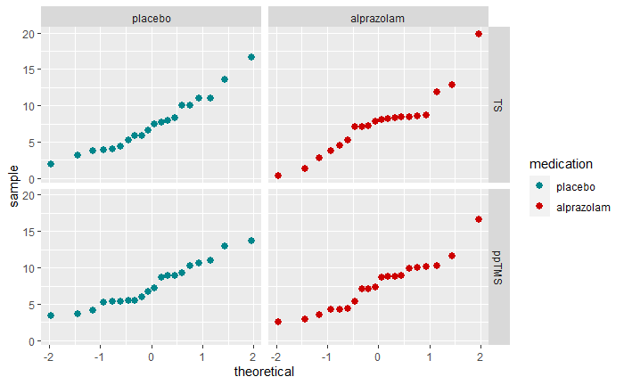

```r
# ---- NORMALITY TEST ----
# QQ-plot
data %>%
  ggplot(aes(sample = amplitude, col = medication)) +
  geom_qq(size = 2.5) +
  facet_grid(stimulus ~ medication) +
  scale_color_manual(values = col_palette[c(2, 4)])
```

```r
# Shapiro-Wilk test
data %>%
  group_by(stimulus, medication) %>%
  shapiro_test(amplitude)
```

| medication | stimulus | variable | statistic | p |
| --- | --- | --- | --- | --- |
| placebo | TS | amplitude | 0.9505 | 0.37484 |
| alprazolam | TS | amplitude | 0.9023 | 0.04546 |
| placebo | ppTMS | amplitude | 0.9426 | 0.26849 |
| alprazolam | ppTMS | amplitude | 0.9373 | 0.21307 |

```r
NA
```

### Data transformation

Transformations are applied only when needed - in the case of a non-normal distribution. The code below tests two possible transformations - square root and log transform with the base 2 - and their effect on the final distribution.

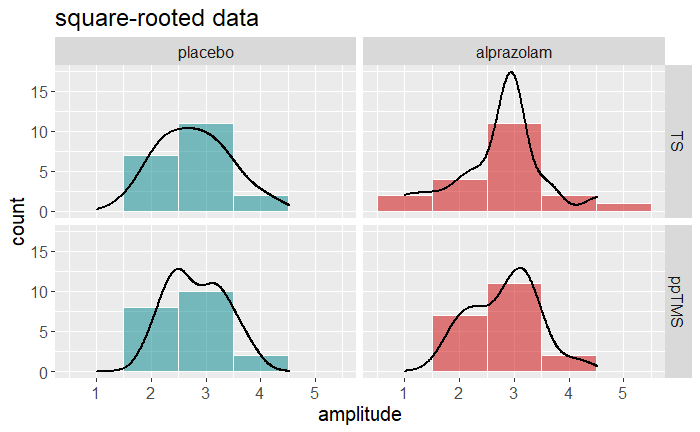

```r
# constants --> onset to positive values
c <- -min(data$amplitude) + 1
data_trans <- data %>%
  # filter(!(subject %in% remove_subj)) %>%
  mutate(amplitude = amplitude + c)

# reflect if negatively skewed
# data_trans <- data_trans %>%
#   group_by(stimulus, medication) %>%
#   mutate(amplitude = max(data_trans$amplitude) - amplitude + 1)

# ---- SQUARE ROOT ----
# create new variable
data_trans <- data_trans %>%
  mutate(amplitude_sqrt = sqrt(amplitude))

# plot by mediation
data_trans %>%
  ggplot(aes(x = amplitude_sqrt, y = ..count.., fill = medication)) +
  geom_histogram(binwidth = 1, col = 'white', alpha = 0.5) +
  geom_density(alpha = 0, size = 1) +
  facet_grid(stimulus ~ medication) +
  ggtitle('square-rooted data') +
  ylab('count') +
  xlab('amplitude') +
  theme(text = element_text(size = 15), legend.position = 'none') +
  scale_fill_manual(values = col_palette[c(2, 4)])
```

```r
# Shapiro-Wilk test
data_trans %>%
  group_by(stimulus, medication) %>%
  shapiro_test(amplitude_sqrt)
```

| medication | stimulus | variable | statistic | p |
| --- | --- | --- | --- | --- |
| placebo | TS | amplitude_sqrt | 0.9836 | 0.9714 |
| alprazolam | TS | amplitude_sqrt | 0.9326 | 0.1733 |
| placebo | ppTMS | amplitude_sqrt | 0.9568 | 0.4813 |
| alprazolam | ppTMS | amplitude_sqrt | 0.9541 | 0.4335 |

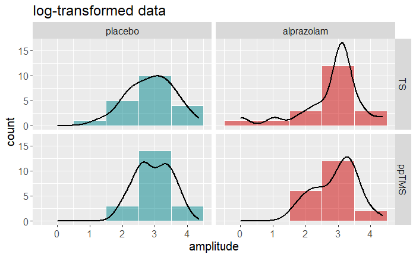

```r
# ---- LOG TRANSFORM ----
# create new variable
data_trans <- data_trans %>%
  mutate(amplitude_log2 = log2(amplitude))

# plot by mediation
data_trans %>%
  ggplot(aes(x = amplitude_log2, y = ..count.., fill = medication)) +
  geom_histogram(binwidth = 1, col = 'white', alpha = 0.5) +
  geom_density(alpha = 0, size = 1) +
  facet_grid(stimulus ~ medication) +
  ggtitle('log-transformed data') +
  ylab('count') +
  xlab('amplitude') +
  theme(text = element_text(size = 15), legend.position = 'none') +
  scale_fill_manual(values = col_palette[c(2, 4)])
```

```r
# Shapiro-Wilk test
data_trans %>%
  group_by(stimulus, medication) %>%
  shapiro_test(amplitude_log2)
```

| medication | stimulus | variable | statistic | p |
| --- | --- | --- | --- | --- |
| placebo | TS | amplitude_log2 | 0.9852 | 0.983018 |
| alprazolam | TS | amplitude_log2 | 0.8543 | 0.006293 |
| placebo | ppTMS | amplitude_log2 | 0.9600 | 0.543364 |
| alprazolam | ppTMS | amplitude_log2 | 0.9438 | 0.282465 |

### Outlier rejection

If a serious outlier is identified, the subject might be removed from the dataset. This step is an option if transformations don’t prove helpful.

```r
# outlier threshold
out_threshold <- data %>%
  group_by(stimulus, medication) %>%
  summarize(a = quantile(amplitude, 0.75) - 1.5*IQR(amplitude), b = quantile(amplitude, 0.75) + 1.5*IQR(amplitude))
out_threshold %>%
  knitr::kable()
```

| stimulus | medication | a | b |
| --- | --- | --- | --- |
| TS | placebo | 1.483 | 18.65 |
| TS | alprazolam | 3.304 | 13.70 |
| ppTMS | placebo | 3.205 | 15.90 |
| ppTMS | alprazolam | 1.651 | 18.19 |

```r
# idenntify outliers
outliers <- boxplot.stats(data %>% group_by(stimulus, medication) %>% pull(amplitude))$out
outliers_index <- which(data %>% group_by(stimulus, medication) %>% pull(amplitude) %in% c(outliers))
data[outliers_index,]
```

| subject | medication | stimulus | amplitude |
| --- | --- | --- | --- |
| 10 | alprazolam | TS | 19.78 |

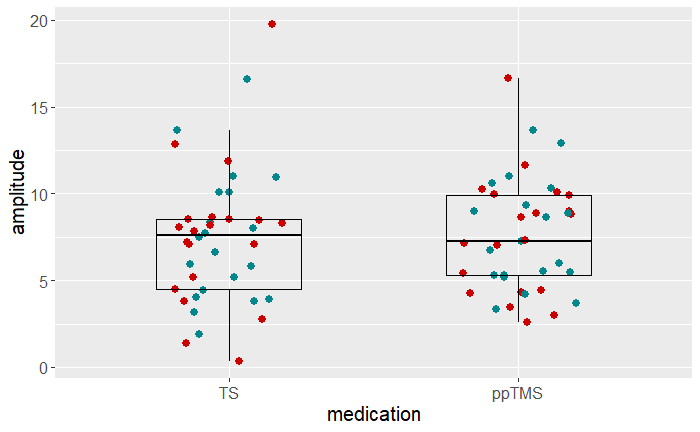

```r
# boxplot
data %>%
  ggplot(aes(stimulus, amplitude, col = medication)) +
  geom_jitter(width = 0.2, size = 2.5, show.legend = FALSE) +
  scale_color_manual(values = col_palette[c(2, 4)]) +
  geom_boxplot(col = 'black', alpha = 0, width = 0.5) +
  ylab('amplitude') +
  xlab('medication') +
  theme(text = element_text(size = 15))
```

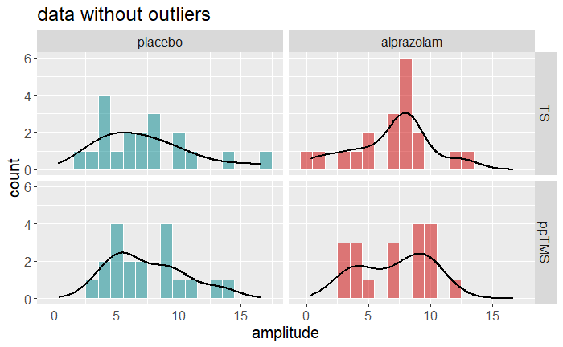

```r
# choose which outliers to remove
remove_subj <- data$subject[outliers_index[c(1)]]

# plot by medication
data %>%
  filter(!(subject %in% remove_subj)) %>%
  ggplot(aes(x = amplitude, y = ..count.., fill = medication)) +
  geom_histogram(binwidth = 1, col = 'white', alpha = 0.5) +
  geom_density(alpha = 0, size = 1) +
  facet_grid(stimulus ~ medication) +
  ggtitle('data without outliers') +
  ylab('count') +
  xlab('amplitude') +
  theme(text = element_text(size = 15), legend.position = 'none') +
  scale_fill_manual(values = col_palette[c(2, 4)])
```

```r
# Shapiro-Wilk test
data %>%
  filter(!(subject %in% remove_subj)) %>%
  group_by(stimulus, medication) %>%
  shapiro_test(amplitude)
```

| medication | stimulus | variable | statistic | p |
| --- | --- | --- | --- | --- |
| placebo | TS | amplitude | 0.9383 | 0.2456 |
| alprazolam | TS | amplitude | 0.9326 | 0.1932 |
| placebo | ppTMS | amplitude | 0.9346 | 0.2107 |
| alprazolam | ppTMS | amplitude | 0.9268 | 0.1514 |

```r
NA
```

### Build models and compare

Based on the previous exploration, choose appropriate adjustment to the data.

```r
# choose transformation if necessary
trans <- readline(prompt = "Use transformation: ")
sqrt
if(trans == 'sqrt'){
  data <- data %>%
    mutate(amplitude_model = data_trans$amplitude_sqrt)
}
if(trans == 'log'){
  data <- data %>%
  mutate(amplitude_model = data_trans$amplitude_log2)
}
if(trans == 'none'){
  data <- data %>%
  mutate(amplitude_model = amplitude)
}

# remove outliers if necessary
out <- askYesNo('Do you want to filter out ouliers?')
if(out){
  data <- filter(data, !subject %in% remove_subj)
}
```

Model n. 1: simple linear regression without random effects

```r
model_lm <- lm(amplitude_model ~ stimulus + medication,
  data = data
)
summary(model_lm)
```

```
Call:
lm(formula = amplitude_model ~ stimulus + medication, data = data)

Residuals:
    Min      1Q  Median      3Q     Max
-1.7592 -0.4313  0.0658  0.3524  1.7617

Coefficients:
             Estimate Std. Error t value Pr(>|t|)
(Intercept)   2.79531    0.07179   38.93   <2e-16 ***
stimulus.L    0.04154    0.10153    0.41     0.68
medication.L -0.00946    0.10153   -0.09     0.93
---
Signif. codes:  0 ‘***’ 0.001 ‘**’ 0.01 ‘*’ 0.05 ‘.’ 0.1 ‘ ’ 1

Residual standard error: 0.642 on 77 degrees of freedom
Multiple R-squared:  0.00228,   Adjusted R-squared:  -0.0236
F-statistic: 0.088 on 2 and 77 DF,  p-value: 0.916
```

```r
confint(model_lm)
```

```
               2.5 % 97.5 %
(Intercept)   2.6524 2.9383
stimulus.L   -0.1606 0.2437
medication.L -0.2116 0.1927
```

Model n. 2: empty model with random intercept

```r
model_ri <- lmer(
  amplitude_model ~ 1 + (1|subject),
  data = data
)
summary(model_ri)
```

```
Linear mixed model fit by REML. t-tests use Satterthwaite's method ['lmerModLmerTest']
Formula: amplitude_model ~ 1 + (1 | subject)
   Data: data

REML criterion at convergence: 101.5

Scaled residuals:
    Min      1Q  Median      3Q     Max
-2.4627 -0.6489 -0.0658  0.6573  2.2131

Random effects:
 Groups   Name        Variance Std.Dev.
 subject  (Intercept) 0.304    0.552
 Residual             0.110    0.332
Number of obs: 80, groups:  subject, 20

Fixed effects:
            Estimate Std. Error     df t value Pr(>|t|)
(Intercept)    2.795      0.129 19.000    21.7  7.2e-15 ***
---
Signif. codes:  0 ‘***’ 0.001 ‘**’ 0.01 ‘*’ 0.05 ‘.’ 0.1 ‘ ’ 1
```

```r
confint(model_ri)
```

```
Computing profile confidence intervals ...
```

```
             2.5 % 97.5 %
.sig01      0.3896 0.7759
.sigma      0.2800 0.4010
(Intercept) 2.5369 3.0537
```

Model n. 3: predictor variables + random intercept

```r
model_rip <- lmer(
  amplitude_model ~ stimulus + medication + (1|subject),
  data = data
)
summary(model_rip)
```

```
Linear mixed model fit by REML. t-tests use Satterthwaite's method ['lmerModLmerTest']
Formula: amplitude_model ~ stimulus + medication + (1 | subject)
   Data: data

REML criterion at convergence: 108.9

Scaled residuals:
    Min      1Q  Median      3Q     Max
-2.3332 -0.5740 -0.0526  0.6754  2.3017

Random effects:
 Groups   Name        Variance Std.Dev.
 subject  (Intercept) 0.304    0.551
 Residual             0.112    0.335
Number of obs: 80, groups:  subject, 20

Fixed effects:
             Estimate Std. Error       df t value Pr(>|t|)
(Intercept)   2.79531    0.12884 18.99999   21.70  7.2e-15 ***
stimulus.L    0.04154    0.05302 58.00000    0.78     0.44
medication.L -0.00946    0.05302 58.00000   -0.18     0.86
---
Signif. codes:  0 ‘***’ 0.001 ‘**’ 0.01 ‘*’ 0.05 ‘.’ 0.1 ‘ ’ 1

Correlation of Fixed Effects:
            (Intr) stml.L
stimulus.L  0.000
medicatin.L 0.000  0.000
```

```r
confint(model_rip)
```

```
Computing profile confidence intervals ...
```

```
                2.5 %  97.5 %
.sig01        0.38999 0.77609
.sigma        0.27847 0.39878
(Intercept)   2.53689 3.05374
stimulus.L   -0.06229 0.14537
medication.L -0.11329 0.09436
```

```r
anova(model_ri, model_rip)
```

```
refitting model(s) with ML (instead of REML)
```

```
Data: data
Models:
model_ri: amplitude_model ~ 1 + (1 | subject)
model_rip: amplitude_model ~ stimulus + medication + (1 | subject)
          npar AIC BIC logLik deviance Chisq Df Pr(>Chisq)
model_ri     3 105 112  -49.6     99.2
model_rip    5 108 120  -49.3     98.5  0.66  2       0.72
```

Describe the full model using the nlme package in order to extract the p-value of the predictor.

```r
# choose the model to retain
model <- lme(
  amplitude_model ~ stimulus + medication,
  random = ~ 1|subject,
  data = data,
  method = 'ML'
)


# fixed effects
broom.mixed::tidy(model, effects = 'fixed') %>%
  knitr::kable()
```

| term | estimate | std.error | df | statistic | p.value |
| --- | --- | --- | --- | --- | --- |
| (Intercept) | 2.7953 | 0.1280 | 58 | 21.8391 | 0.0000 |
| stimulus.L | 0.0415 | 0.0531 | 58 | 0.7818 | 0.4375 |
| medication.L | -0.0095 | 0.0531 | 58 | -0.1781 | 0.8592 |

```r
# fixed effects
broom.mixed::tidy(model, effects = 'ran_pars') %>%
  knitr::kable()
```

| effect | group | term | estimate |
| --- | --- | --- | --- |
| ran_pars | subject | sd_(Intercept) | 0.5368 |
| ran_pars | Residual | sd_Observation | 0.3297 |

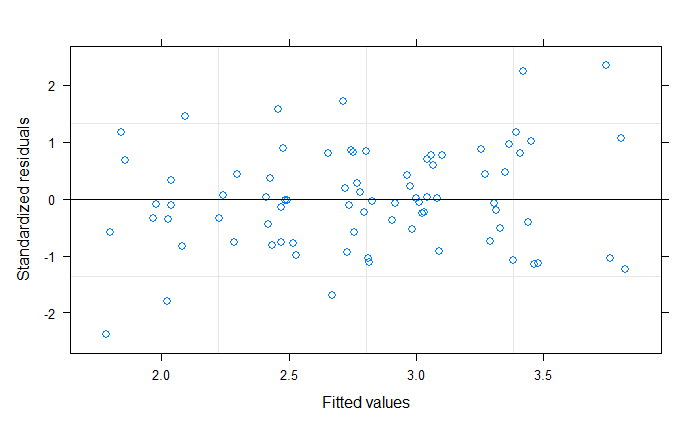

```r
# residuals
plot(model)
```

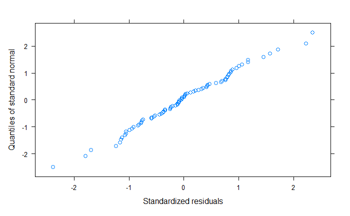

```r
qqnorm(model)
```

Estimate p values using the Kenward-Roger approximation

```r
anova(model_rip, ddf="Kenward-Roger") %>%
  knitr::kable()
```

|  | Sum Sq | Mean Sq | NumDF | DenDF | F value | Pr(>F) |
| --- | --- | --- | --- | --- | --- | --- |
| stimulus | 0.0690 | 0.0690 | 1 | 58 | 0.6139 | 0.4365 |
| medication | 0.0036 | 0.0036 | 1 | 58 | 0.0319 | 0.8589 |